# Session03

Susumu Shikano

Last compiled at 26. Juli 2022

## Binomial distribution

We can start to observe the PMF of a binomial distribution:

```r
p <- 0.5
n <- 4

print(pmf <- dbinom(0:n,size=n,prob=p))
```

```
## [1] 0.0625 0.2500 0.3750 0.2500 0.0625
```

These values are the probablity of each possible outcomes: 0,1,2,…,n.

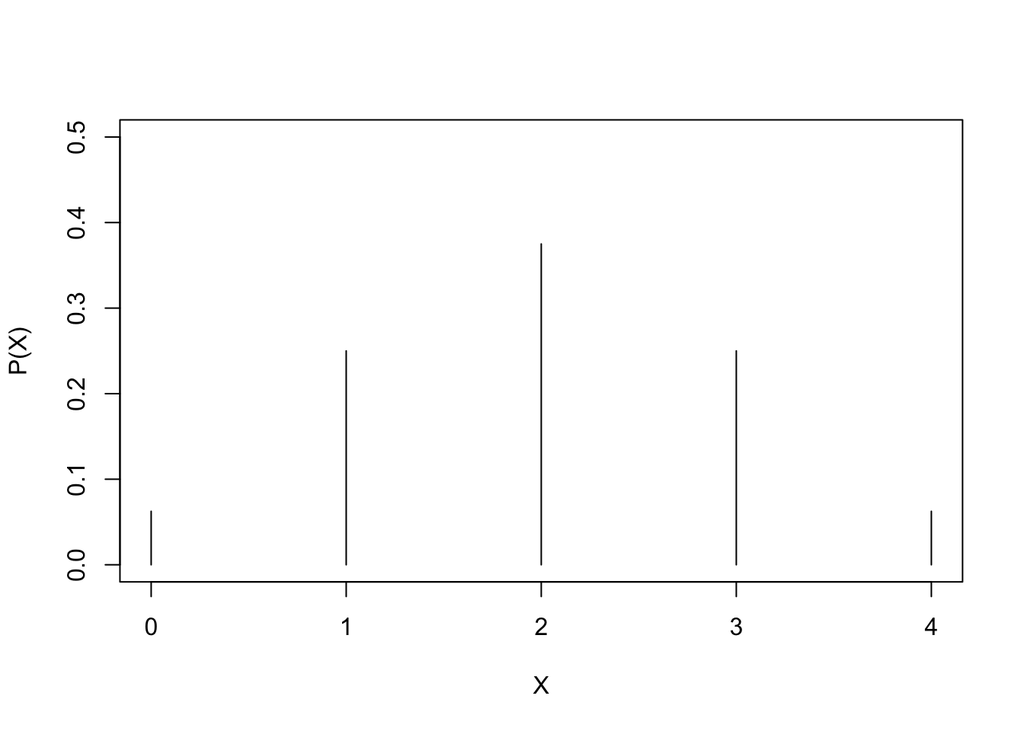

```r
plot(0:n,pmf,type="h",
     ylab="P(X)",xlab="X",ylim=c(0,0.5))
```

We can also check the CDF:

```r
cdf <- pbinom(0:n,size=n,prob=p)

cbind(pmf,cdf)
```

```
##         pmf    cdf
## [1,] 0.0625 0.0625
## [2,] 0.2500 0.3125
## [3,] 0.3750 0.6875
## [4,] 0.2500 0.9375
## [5,] 0.0625 1.0000
```

It is evident that CDF is the cummulated PMF.

Now, we can also generate random variables by using the same binonial distribution:

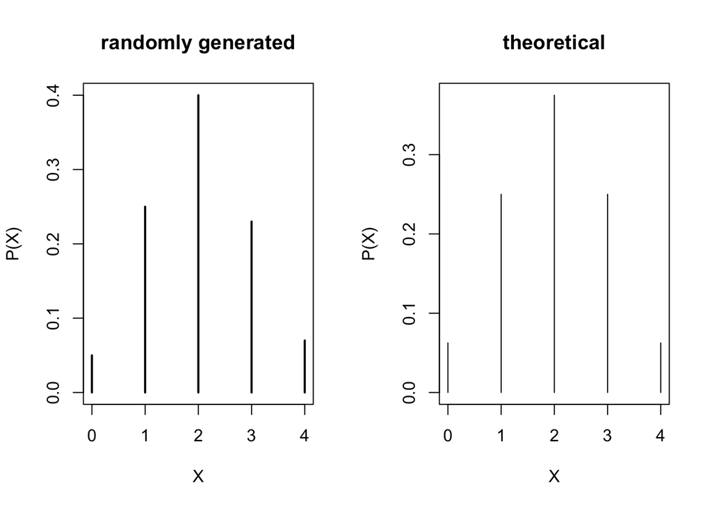

```r
sample.size <- 100

random.var <- rbinom(sample.size,size=n,prob=p)

par(mfrow=c(1,2))

plot(table(random.var)/length(random.var),type="h",
     ylab="P(X)",xlab="X",main="randomly generated")

plot(0:n,pmf,type="h",
     ylab="P(X)",xlab="X",main="theoretical",
     ylim=c(0,max(pmf)))
```

They are not perfectly identical, but if you increase the sample size, both the distribution of the randomly generated variable converges to the theoretical one.

If you further increase the number of trials (n), the distribution converges to a normal distribution.

### Expectation and further moments

The expectation and variance of the binomial distribution is known. The mean value can be obtained by using PMF:

```r
sum(c(0:n)*pmf)
```

```
## [1] 2
```

This corresponds always to $n \times p$. The variance is:

```r
sum( (c(0:n) - (n*p))^2   *pmf)
```

```
## [1] 1
```

The result always corresponds to $n \times p \times (1-p)$.

These results can be also approximated with the randomly generatd variable:

```r
mean(random.var)
```

```
## [1] 2.02
```

```r
mean((random.var-mean(random.var))^2)
```

```
## [1] 0.9596
```

Again these values are not perfectly identical with the above results, but they will be closer if we increase the sample size.

### Independence of two binomial distributions

We generate another random variable using another binomial distribution independently:

```r
random.var2 <- rbinom(sample.size,size=n+5,prob=p/2)
```

We can observe both variables in their probabilities:

```r
table(random.var)/(length(random.var))
```

```
## random.var
##    0    1    2    3    4
## 0.05 0.25 0.40 0.23 0.07
```

```r
table(random.var2)/(length(random.var2))
```

```
## random.var2
##    0    1    2    3    4    5    6
## 0.04 0.21 0.33 0.17 0.15 0.08 0.02
```

Let’s observe the probability that both random variables have the value 1:

```r
mean(random.var==1 & random.var2==1)
```

```
## [1] 0.04
```

This value is close to the product of the probability that each variable has the value 1:

```r
mean(random.var==1) * mean(random.var2==1)
```

```
## [1] 0.0525
```